# Carrier On-Time and Delay Performance (1987-present)

## by (Nehal Nabil)

## Preliminary Wrangling

> The dataset reports flights in the United States, including carriers, arrival and departure delays from 1987 to 2020. The report will gather & analyze flights ofJanuary in these years (1988, 1995, 2000, 2007, 2015, 2020) and start to resolve the following questions :

> > What are the best US cities in terms of no. of Flights and delayed and cancelled flighes?

> > What are the best airlines in terms of no. of Flights and delayed and cancelled flighes?

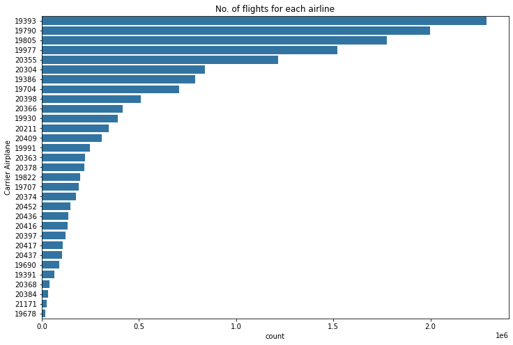

> There is an obvious differnce among airlines in flights' number. it's clear that carier airline (19393) has more than 2 million flights among the selected years while another courier airlines like (19678) has less than 500000 flights.

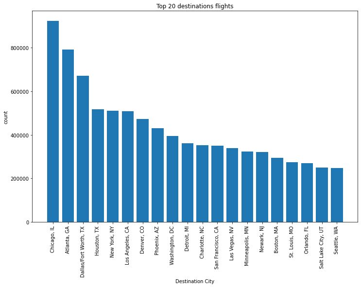

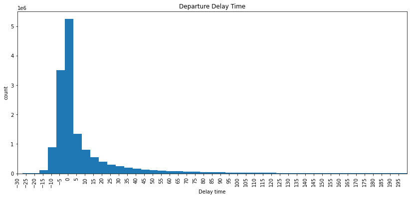

> Delay ratio is concenterated between -12 to 25 minutes, and the distribution is skewed to the right

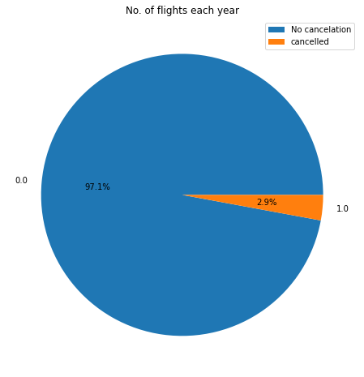

> The chart clarifies that among the selected years,cancellation rate was small as it's less than 3% of the total flights.

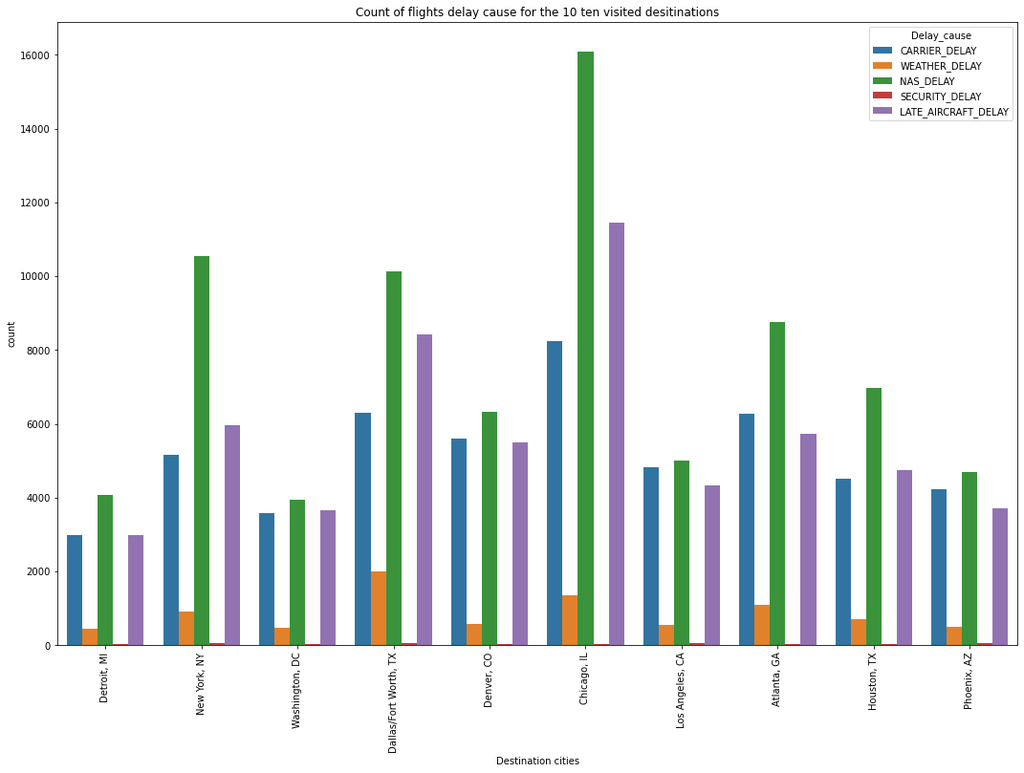

> The chart shows that for the 10 displayed cities, highest delay cause is National Air System Delay but in some cities it has a very high count coparing to ther cities and to other causes in the same city. e.g : Chicago and New York.

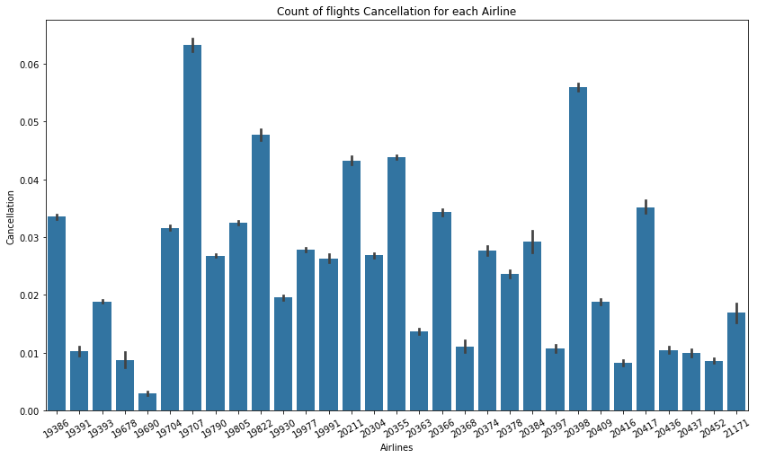

> There's a variation in the cancellation rates among airlines. The chart shows that airline (19707) has the highest cancellation rate among the chosen years while airline (19690) has the lowest one.

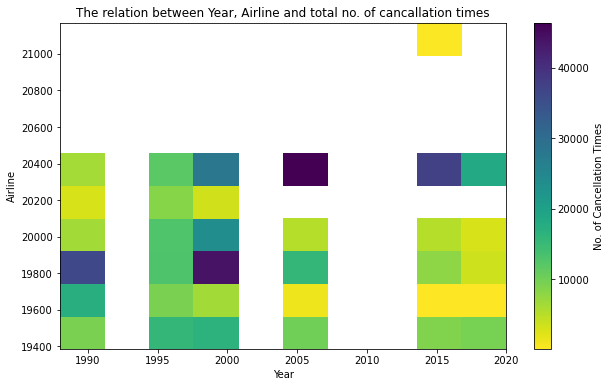

> The chart shows that year 2005 and 2000 has the highest rate of cancellation paired with 20400, 19800 airlines respectively. It also shows that most airlines has less cancellation rates through years.

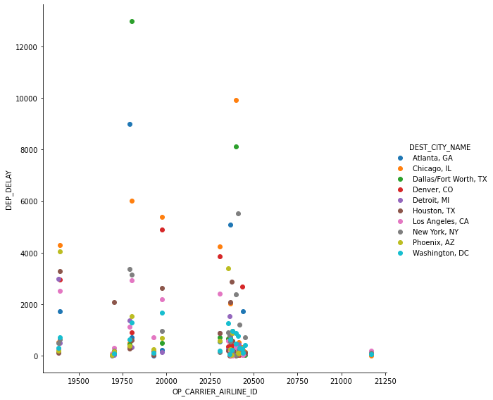

> The chart shows that Chicago has the highest delay rates in more than three airlines. Also there's one specific airline that has extremely high rates of delay for Dallas city